# PAC_3 software analisi de dades

Raúl Pérez Prats

2023-12-06

## Models i machine learning

Carreguem les dades sobre les que treballarem:

```r
index = read.table("https://bit.ly/3gzYaUP", header = TRUE)
```

### Exercici 1

#### A)

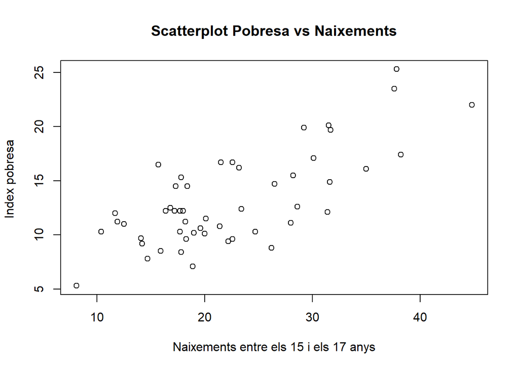

```r
plot(index$Brth15to17,index$PovPct,main="Scatterplot Pobresa vs Naixements",
      xlab="Naixements entre els 15 i els 17 anys", ylab="Index pobresa ",lty = 1)
```

Podem observar que el núvol de punts tot i tenir una tendència a augmentar l’índex de pobresa amb el major nombre de naixements entre els 15 i els 17 es dispers i presenta molts outliers.

#### B)

```r
model = lm(PovPct~Brth15to17,data = index) #Create a linear regression with two variables
summary(model) #Review the results
```

```
##
## Call:
## lm(formula = PovPct ~ Brth15to17, data = index)
##
## Residuals:
##     Min      1Q  Median      3Q     Max
## -5.8390 -2.0532 -0.2401  2.4201  6.1562
##
## Coefficients:
##             Estimate Std. Error t value Pr(>|t|)
## (Intercept)  4.46447    1.22799   3.636 0.000665 ***
## Brth15to17   0.38834    0.05189   7.483 1.19e-09 ***
## ---
## Signif. codes:  0 '***' 0.001 '**' 0.01 '*' 0.05 '.' 0.1 ' ' 1
##
## Residual standard error: 2.952 on 49 degrees of freedom
## Multiple R-squared:  0.5333, Adjusted R-squared:  0.5238
## F-statistic:    56 on 1 and 49 DF,  p-value: 1.188e-09
```

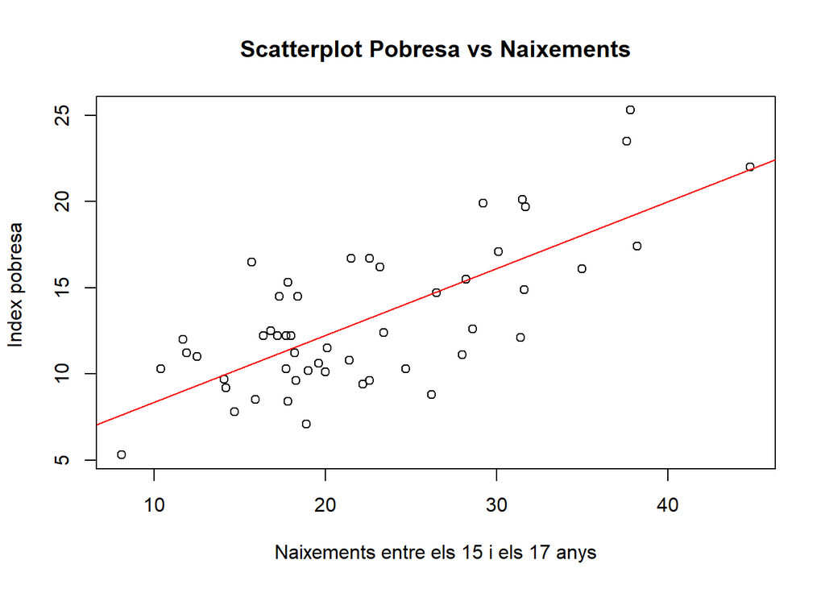

```r
plot(index$Brth15to17,index$PovPct,main="Scatterplot Pobresa vs Naixements",
      xlab="Naixements entre els 15 i els 17 anys", ylab="Index pobresa ",lty = 1)

abline(model, col="red") # regression line (y~x)
```

L’ajust del model es de 0.52 segons la R^2 ajustada. Aquest coeficient indica que el model de regressió linial s’ajusta lleugerament a les dades i suggereix que aquestes tenen una tendència lleugerament positiva, lo qual indica que a major nombre de naixements entre els 15 i els 17 anys en una zona, major son els índex de pobresa. Tot i així el model segueix estant lluny de obtenir un coeficient de correlació proper a 1, on si que podriem afirmar de forma significativa i indiscutible aquesta correlació

#### C)

Podem observar que el model de regressió lineal no s’ajusta completament a aquest tipus de dades si mirem els errors residuals que presenta, ja que el mínim es de -5.8 i el maxim es de 6.15, son errors elevats que ens permeten veure el desajust de la regressió lineal.

Per una altra banda obtenim p-valors significatius per a els coeficients que hem triat per a realiztar el model de regressió lineal, per tant, tot i no ajustar-se completament a una correlació positiva, els paràmetres utilitzats son els adecuats. Podria millorar-se l’ajust de la regressió lineal augmentant el nombre de les dades mitjançant mostrejos representatius, per tal d’aconseguir més potència estadística i així reduir el pes dels outliers en el model final.